Name - Janhavee Kanoje

GH Number - GH1033705

Subject Code - M507A (Methods of Prediction)

Professor's Name - Dr. Mohammad Madhavi

**Introduction**

Business Problem - Damage in infrastructure can raise serious safety concerns and yet is very necessory to kept in a adequate condition. however, inspecting them manually is very time consuming and needs a lot of labor source. By using this pipeline, we can analyze and supervise different surface conditions in a time-effective and cost-effective way.

Data source for this model is: https://www.kaggle.com/datasets/arunrk7/surface-crack-detection/data

This idea can be formulated in a machine learning task.

Problem statement - Develop Deep learning model that can identify cracks in infrastucture and identify positive or negative. (positive = cracks; negative = no cracks)

**Import Required Packages**

```python
import numpy as np
import pandas as pd
import tensorflow as _tf_
from tensorflow import keras
import matplotlib.pyplot as plt
import zipfile
import os
import seaborn as sns
import warnings
warnings.filterwarnings("ignore")
from tensorflow.keras import layers
from keras import optimizers , callbacks
from keras.callbacks import EarlyStopping, ReduceLROnPlateau
from keras.utils import image_dataset_from_directory
from keras.optimizers import SGD, Adam
from keras.models import Sequential
from tensorflow.keras.layers import Conv2D, MaxPooling2D, Flatten, Dense, Dropout, BatchNormalization, ReLU, LeakyReLU
from sklearn.metrics import classification_report, confusion_matrix
import time
import random
import warnings
```

### **Load Data**

Load the zip file and define the directory in new loaction. Read the dataset.

The dataset has two labels - Negative and Positive

```python
zip_Dir = "/content/sample_data/archive (1).zip"
Data_Dir = '/content/defect_dataset_raw'

with zipfile.ZipFile(zip_Dir, 'r') as zip_ref:
    zip_ref.extractall(Data_Dir)

    print(os.listdir(Data_Dir))
```

```
['Negative', 'Positive']
```

Image height, image width and batch size is defined.

```python
src_height = 32
src_width = 32
batch_size = 16

image_set = image_dataset_from_directory(Data_Dir,
        seed=123,
        image_size = (src_height , src_width),
        batch_size = batch_size )
```

```
Found 40000 files belonging to 2 classes.
```

```python
class_names = image_set.class_names
print(class_names)
```

```
['Negative', 'Positive']
```

### **Data Visualization**

Visualize the data samples.

```python
def image_samples(dataset, class_names):
    batch = next(iter(dataset))
    images, labels = batch

    fig, axes = plt.subplots(3, 3, figsize=(8, 8))
    for i, ax in enumerate(axes.flat):
        ax.imshow(images[i].numpy().astype("uint8"))
        ax.set_title(class_names[labels[i]])
        ax.axis('off')

    plt.tight_layout()
    plt.show()
```

From the images we can see that the evident cracks in the infrastructure are visible and can be classified.

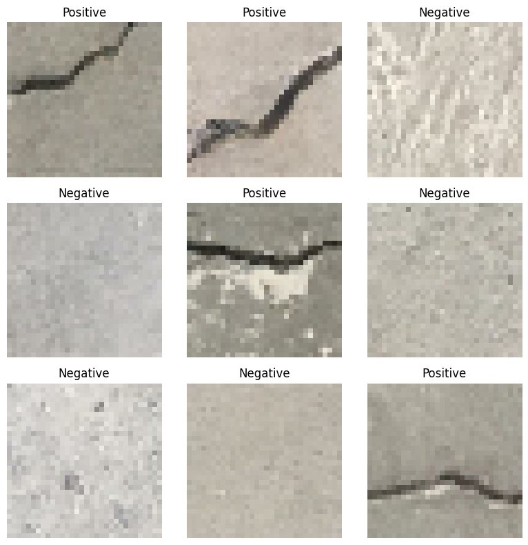

```python
image_samples(image_set, class_names)
```

### **Preprocessing**

Scale the image dataset, to avoid gradient decent issues and improve the model performance.

Use one hot encoding to avoid none value errors.

```python
def scale_img(image, label):
  image = image / 255.0

  label = _tf_.one_hot(label, depth=len(class_names))
  return image, label

scaled_image_set = image_set.map(scale_img)
```

### **Split Data**

Define dataset size and split scaled data into train, validation and test sets.

```python
size_dataset = _tf_.data.experimental.cardinality(scaled_image_set).numpy()
model_train = int(0.8 * size_dataset)
model_val = int(0.1 * size_dataset)
model_test = size_dataset - model_train - model_val

model_new_train = scaled_image_set.take(model_train)
model_new_val = scaled_image_set.skip(model_train).take(model_val)
model_new_test = scaled_image_set.skip(model_train + model_val)
```

### **Build CNN model**

Perform tuning to analyse the effect to key changes made in the model and how it impacts the accuracy and loss scores of the trained model.

```python
model = keras.Sequential()

model.add(layers.Rescaling(1./255, input_shape=(src_height, src_width, 3)))

model.add(layers.Conv2D(16, (5, 5), padding="same"))
model.add(layers.LeakyReLU(alpha=0.1))
model.add(layers.BatchNormalization())
model.add(layers.MaxPooling2D())

model.add(layers.Conv2D(32, (5, 5), padding="same"))
model.add(layers.LeakyReLU(alpha=0.1))
model.add(layers.BatchNormalization())
model.add(layers.MaxPooling2D())

model.add(layers.Conv2D(32, (5, 5), padding="same"))
model.add(layers.LeakyReLU(alpha=0.1))
model.add(layers.BatchNormalization())
model.add(layers.MaxPooling2D())

model.add(layers.Conv2D(64, (5, 5), padding="same"))
model.add(layers.LeakyReLU(alpha=0.1))
model.add(layers.BatchNormalization())
model.add(layers.MaxPooling2D())

model.add(layers.Flatten())

model.add(layers.Dense(256))
model.add(layers.LeakyReLU(alpha=0.1))
model.add(layers.Dropout(0.5))
model.add(layers.Dense(128))
model.add(layers.LeakyReLU(alpha=0.1))
model.add(layers.Dropout(0.3))
model.add(layers.Dense(2, activation="softmax"))

sgd = SGD(learning_rate=0.0025, momentum=0.95)
model.compile(loss='categorical_crossentropy', optimizer=sgd, metrics=['accuracy'])
```

### **Initialize callbacks**

Initialize earlystoping to save time and improve computational efficiency and learning rate to prevent overfitting and improve convergence.

```python
model_early_stop = EarlyStopping(
    monitor='val_loss',
    min_delta=0.001,
    patience=5,
    verbose=1,
    start_from_epoch = 3)

lr_model = ReduceLROnPlateau(
    monitor='val_loss',
    verbose=1,
    factor=0.5,
    patience=5,
    min_delta=0.001,
    min_lr= 1e-5)
```

**Train Model**

Fit the model and note the training time.

```python
train_initilize = time.time()

model_history = model.fit(model_new_train, epochs=30, validation_data=model_new_val,
                         callbacks=[lr_model, model_early_stop])

finish_train = time.time()
total_time = finish_train - train_initilize
print(f"\nFinished training in {(total_time//60):.0f} minutes and {(total_time%60):.1f} seconds")
```

Finished training in 13 minutes and 52.2 seconds

**Model Evaluation**

Chages made while tuning the model and their respective accuracy, loss, val_accuracy and val_loss scores.

[figure not shown]

### **Conclusion**

This machine learning pipeline provides a solution to a better and convinient infrastructure supervision technique. This might help in predicting future conditions and necessory mainteinance.

The cracks can be identified, which might help identify the risk associated with it and disasterous situations can be avoided.

There can be sligth drawbacks at the start regarding the accuracy of detecting the damage, but however this can be a effective add on to the supervision industry.